# project2

Petrenko Kate

2022-12-10

В данном проекте мы смотрим на то, как средняя стоимость домов из данных из пакета MASS ?зависит от различных факторов.

В данных есть следующие параметры:

1. crim - уровень преступности на душу населения
2. zn - доля земель под жилую застройку
3. indus - доля акров неторгового бизнеса на город
4. chas - граничит ли участок с рекой
5. nox - концентрация оксидов азота
6. rm - среднее количество комнат
7. age - доля домов, построенных до 1940
8. dis - среднее расстояние до 5 центров занятости
9. rad - индекс доступности к магистралям
10. tax - полная ставка налога на имущество
11. ptrario - соотношение учеников и учителей
12. black - бяка, мне нравится этот критерий… (нехорошо это)
13. lstat - доля населения с невысоким статусом
14. medv - средняя стоимость домов

## Загрузка данных

Наличие реки рядом переводим в факторуню переменную

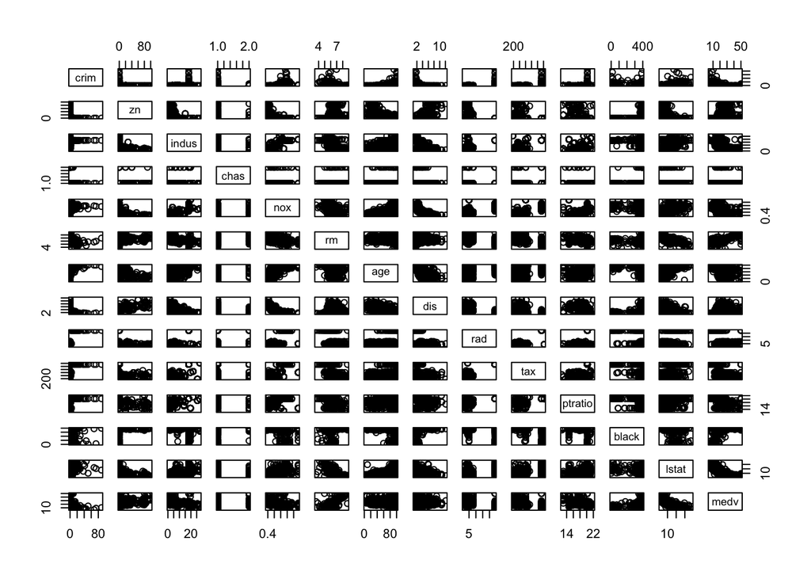

```r
houses <- Boston
houses$chas <- factor(houses$chas)
plot(houses)
```

Судя по графику, некоторые предикторы взаимодействуют друг с другом

## Построение модели

```r
house_sc <- as.data.frame(sapply(houses[, names(houses) != "chas"], scale))
house_sc$chas <- houses$chas
house_model <- lm(medv ~ ., house_sc)
summary(house_model)
```

```
##
## Call:
## lm(formula = medv ~ ., data = house_sc)
##
## Residuals:
##      Min       1Q   Median       3Q      Max
## -1.69559 -0.29680 -0.05633  0.19322  2.84864
##
## Coefficients:
##              Estimate Std. Error t value Pr(>|t|)
## (Intercept) -0.020206   0.023835  -0.848 0.396976
## crim        -0.101017   0.030737  -3.287 0.001087 **
## zn           0.117715   0.034811   3.382 0.000778 ***
## indus        0.015335   0.045871   0.334 0.738288
## nox         -0.223848   0.048126  -4.651 4.25e-06 ***
## rm           0.291056   0.031928   9.116  < 2e-16 ***
## age          0.002119   0.040430   0.052 0.958229
## dis         -0.337836   0.045666  -7.398 6.01e-13 ***
## rad          0.289749   0.062813   4.613 5.07e-06 ***
## tax         -0.226032   0.068912  -3.280 0.001112 **
## ptratio     -0.224271   0.030796  -7.283 1.31e-12 ***
## black        0.092432   0.026662   3.467 0.000573 ***
## lstat       -0.407447   0.039378 -10.347  < 2e-16 ***
## chas1        0.292128   0.093679   3.118 0.001925 **
## ---
## Signif. codes:  0 '***' 0.001 '**' 0.01 '*' 0.05 '.' 0.1 ' ' 1
##
## Residual standard error: 0.516 on 492 degrees of freedom
## Multiple R-squared:  0.7406, Adjusted R-squared:  0.7338
## F-statistic: 108.1 on 13 and 492 DF,  p-value: < 2.2e-16
```

## Проверка линейности взаимосвязи

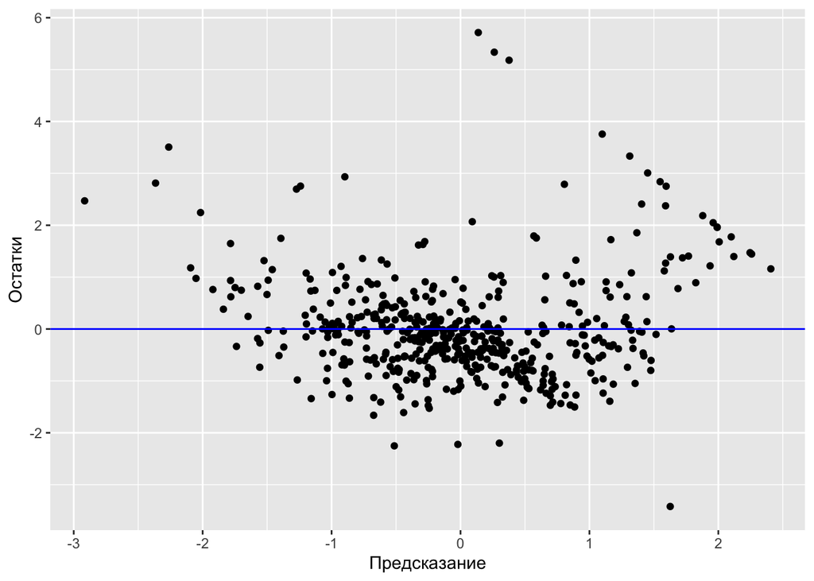

```r
house_model_plot <- data.frame(augment(house_model), house_sc)
ggplot(data = house_model_plot, aes(.fitted, .std.resid)) +
  geom_point() +
  geom_hline(yintercept = 0, color = 'blue') +
  xlab('Предсказание') +
  ylab('Oстатки')
```

Полученный график позволяет сделать вывод о нейлинейности взаимосвязи и непостоянстве дисперсии

## Проверка влиятельных наблюдений

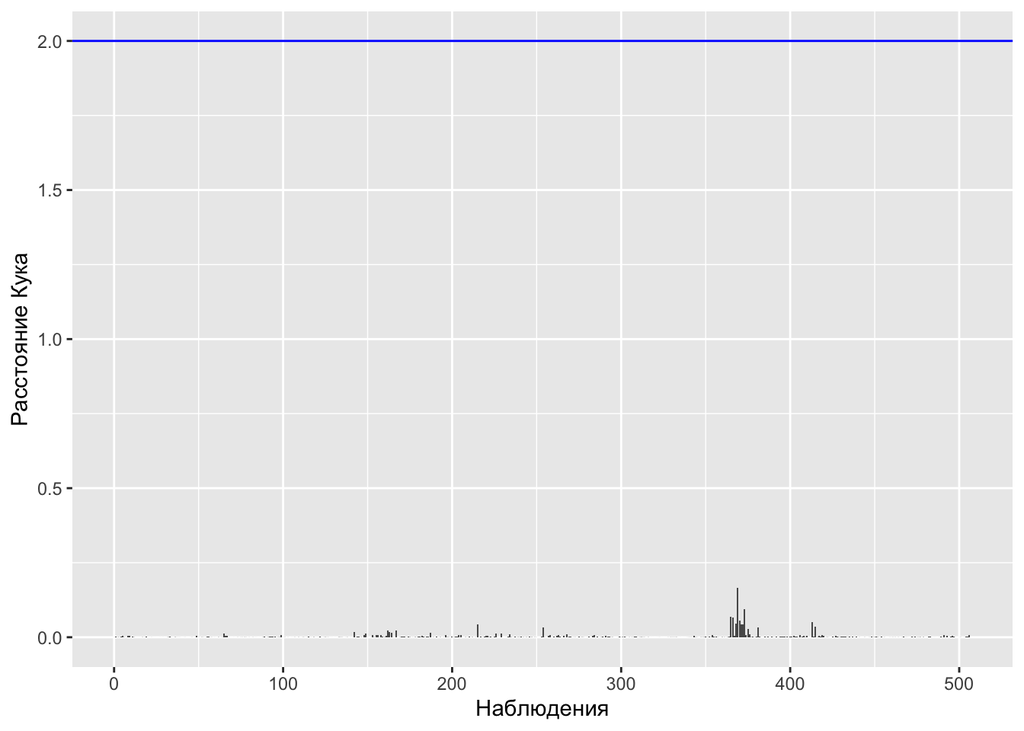

```r
ggplot(house_model_plot, aes(1:nrow(house_model_plot), .cooksd)) +
  geom_hline(yintercept = 2, color = "blue") +
  geom_bar(stat = "identity") +
  xlab('Наблюдения') +
  ylab('Расстояние Кука')
```

Влиятельных наблюдений нет

## Нормальность распределения

```r
shapiro.test(house_model_plot$.std.resid)
```

```
##
##  Shapiro-Wilk normality test
##
## data:  house_model_plot$.std.resid
## W = 0.89878, p-value < 2.2e-16
```

Распределение стандартизированных остатков отличается от нормального

## мультиколлинеарность

так как в структуре данных мы видели корреляции, проверим на мультиколлинеарность

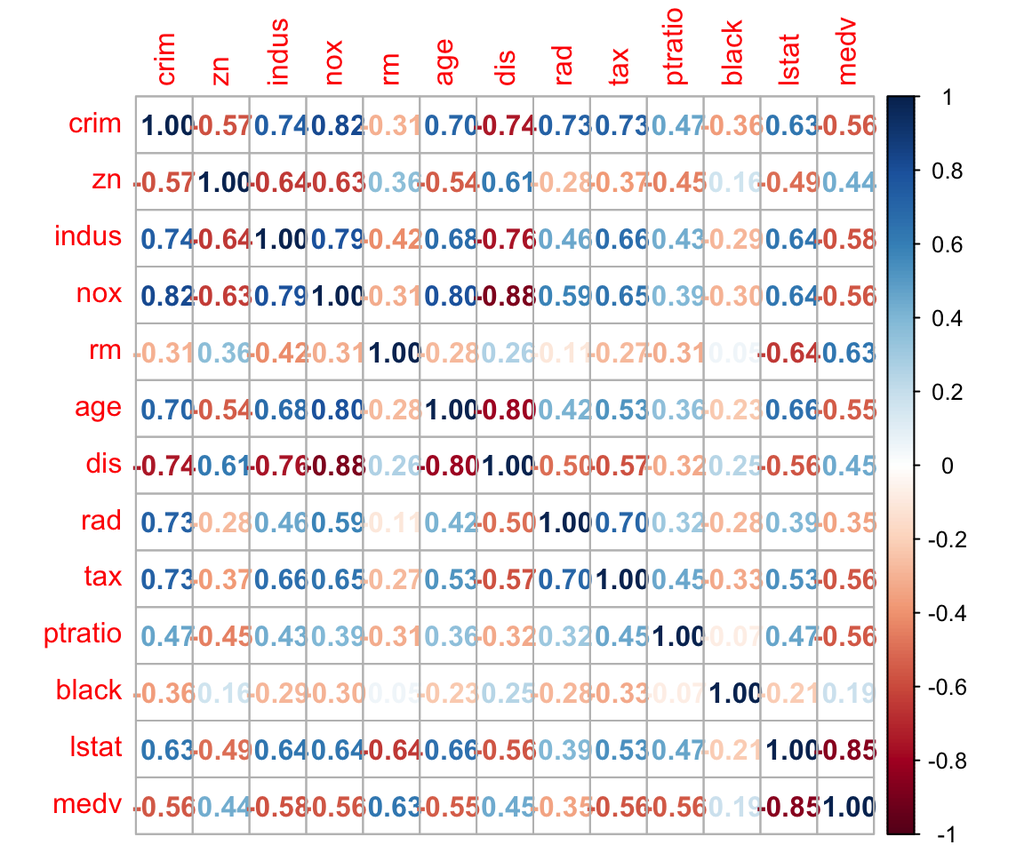

```r
cor_matrix <- cor(houses[, names(houses) != "chas"], method = "s")
corrplot(cor_matrix, method = 'number')
```

Мультиколлинеарность есть

```r
car::vif(house_model)
```

```
##     crim       zn    indus      nox       rm      age      dis      rad
## 1.792192 2.298758 3.991596 4.393720 1.933744 3.100826 3.955945 7.484496
##      tax  ptratio    black    lstat     chas
## 9.008554 1.799084 1.348521 2.941491 1.073995
```

Предикторы со значением выше 2 стоит исключить из модели

## График предсказаний

Переменная с наибольшим коэффициентом - lstat

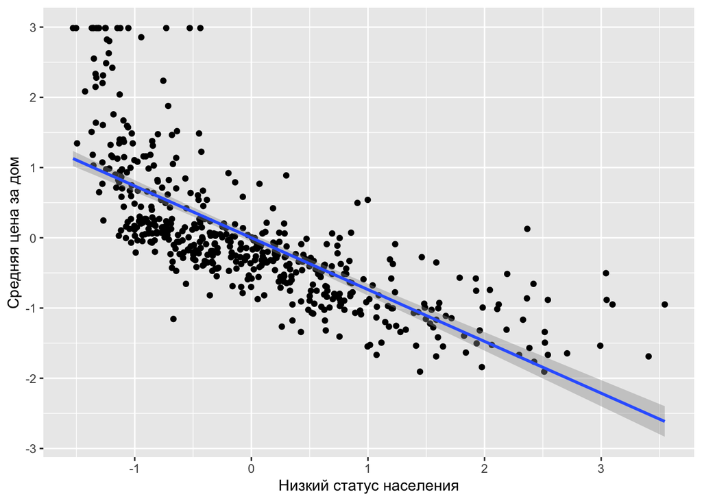

```r
ggplot(house_sc, aes(x = lstat, y = medv)) +
  geom_point() +
  geom_smooth(method = lm) +
  xlab('Низкий статус населения') +
  ylab('Средняя цена за дом')
```

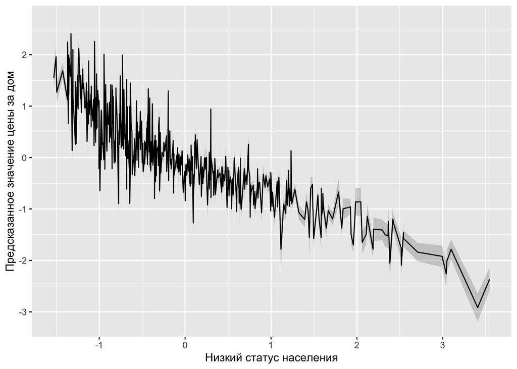

```r
predictions <- predict(house_model,  interval = 'confidence')
predictions_full_data <- data.frame(house_sc, predictions)

ggplot(predictions_full_data, aes(x = lstat, y = fit)) +
  geom_ribbon(alpha = 0.2, aes(ymin = lwr, ymax = upr)) +
  geom_line() +
  xlab('Низкий статус населения') +
  ylab('Предсказанное значение цены за дом')
```

Данная модель не очень хорошо предсказывает значения, необходимо убрать некоторые предикторы

## Улучшение модели

Удаляем предикторы с наибольшим vif, пока все не будут меньше 2

```r
house_model_vif <- car::vif(house_model)
house_model_vif
```

```
##     crim       zn    indus      nox       rm      age      dis      rad
## 1.792192 2.298758 3.991596 4.393720 1.933744 3.100826 3.955945 7.484496
##      tax  ptratio    black    lstat     chas
## 9.008554 1.799084 1.348521 2.941491 1.073995
```

```r
house_model_2 <- update(house_model, .~. - tax)
vif(house_model_2)
```

```
##     crim       zn    indus      nox       rm      age      dis      rad
## 1.791940 2.184240 3.226015 4.369271 1.923075 3.098044 3.954446 2.837494
##  ptratio    black    lstat     chas
## 1.788839 1.347564 2.940800 1.058220
```

```r
house_model_3 <- update(house_model_2, .~. - nox)
vif(house_model_3)
```

```
##     crim       zn    indus       rm      age      dis      rad  ptratio
## 1.785343 2.183394 2.872809 1.904013 2.875130 3.641492 2.533616 1.598944
##    black    lstat     chas
## 1.339554 2.927273 1.057571
```

```r
house_model_4 <- update(house_model_3, .~. - dis)
vif(house_model_4)
```

```
##     crim       zn    indus       rm      age      rad  ptratio    black
## 1.765881 1.758636 2.517520 1.879925 2.423551 2.507024 1.530992 1.339553
##    lstat     chas
## 2.926111 1.056840
```

```r
house_model_5 <- update(house_model_4, .~. - lstat)
vif(house_model_5)
```

```
##     crim       zn    indus       rm      age      rad  ptratio    black
## 1.727110 1.751140 2.489395 1.307312 2.038976 2.497242 1.529761 1.304899
##     chas
## 1.053402
```

```r
house_model_6 <- update(house_model_5, .~. - rad)
vif(house_model_6)
```

```
##     crim       zn    indus       rm      age  ptratio    black     chas
## 1.372553 1.738620 2.229252 1.281667 2.026045 1.369726 1.251785 1.052519
```

```r
house_model_final <- update(house_model_6, .~. - indus)
vif(house_model_final)
```

```
##     crim       zn       rm      age  ptratio    black     chas
## 1.342583 1.680416 1.216701 1.668190 1.345528 1.209887 1.043732
```

## Получение модели на данных без стандартизации

```r
house_model_unsc <- lm(medv ~ ., houses)
house_model_2_unsc <- update(house_model_unsc, .~. - tax)
vif(house_model_2_unsc)
```

```
##     crim       zn    indus     chas      nox       rm      age      dis
## 1.791940 2.184240 3.226015 1.058220 4.369271 1.923075 3.098044 3.954446
##      rad  ptratio    black    lstat
## 2.837494 1.788839 1.347564 2.940800
```

```r
house_model_3_unsc <- update(house_model_2_unsc, .~. - nox)
vif(house_model_3_unsc)
```

```
##     crim       zn    indus     chas       rm      age      dis      rad
## 1.785343 2.183394 2.872809 1.057571 1.904013 2.875130 3.641492 2.533616
##  ptratio    black    lstat
## 1.598944 1.339554 2.927273
```

```r
house_model_4_unsc <- update(house_model_3_unsc, .~. - dis)
vif(house_model_4_unsc)
```

```
##     crim       zn    indus     chas       rm      age      rad  ptratio
## 1.765881 1.758636 2.517520 1.056840 1.879925 2.423551 2.507024 1.530992
##    black    lstat
## 1.339553 2.926111
```

```r
house_model_5_unsc <- update(house_model_4_unsc, .~. - lstat)
vif(house_model_5_unsc)
```

```
##     crim       zn    indus     chas       rm      age      rad  ptratio
## 1.727110 1.751140 2.489395 1.053402 1.307312 2.038976 2.497242 1.529761
##    black
## 1.304899
```

```r
house_model_6_unsc <- update(house_model_5_unsc, .~. - rad)
vif(house_model_6_unsc)
```

```
##     crim       zn    indus     chas       rm      age  ptratio    black
## 1.372553 1.738620 2.229252 1.052519 1.281667 2.026045 1.369726 1.251785
```

```r
house_model_final_unsc <- update(house_model_6_unsc, .~. - indus)
vif(house_model_final_unsc)
```

```
##     crim       zn     chas       rm      age  ptratio    black
## 1.342583 1.680416 1.043732 1.216701 1.668190 1.345528 1.209887
```

```r
summary(house_model_final_unsc)
```

```
##
## Call:
## lm(formula = medv ~ crim + zn + chas + rm + age + ptratio + black,
##     data = houses)
##
## Residuals:
##     Min      1Q  Median      3Q     Max
## -19.344  -2.952  -0.752   1.686  39.739
##
## Coefficients:
##              Estimate Std. Error t value Pr(>|t|)
## (Intercept) -7.059509   4.174778  -1.691 0.091464 .
## crim        -0.107763   0.033452  -3.221 0.001359 **
## zn          -0.003106   0.013803  -0.225 0.822060
## chas1        3.520275   0.998861   3.524 0.000464 ***
## rm           7.064243   0.389859  18.120  < 2e-16 ***
## age         -0.041439   0.011395  -3.637 0.000305 ***
## ptratio     -0.927928   0.133056  -6.974 9.84e-12 ***
## black        0.014984   0.002992   5.008 7.65e-07 ***
## ---
## Signif. codes:  0 '***' 0.001 '**' 0.01 '*' 0.05 '.' 0.1 ' ' 1
##
## Residual standard error: 5.581 on 498 degrees of freedom
## Multiple R-squared:  0.6369, Adjusted R-squared:  0.6318
## F-statistic: 124.8 on 7 and 498 DF,  p-value: < 2.2e-16
```

Итоговая модель:

Если дом не у реки - medv = -7.06 - 0.108 * crim - 0.003 * zn + 7.06 * rm - 0.04 * age - 0.927 * ptratio + 0.015 * black Если у реки - medv = -3.54 - 0.108 * crim - 0.003 * zn + 7.06 * rm - 0.04 * age - 0.927 * ptratio + 0.015 * black

## Тестирование модели

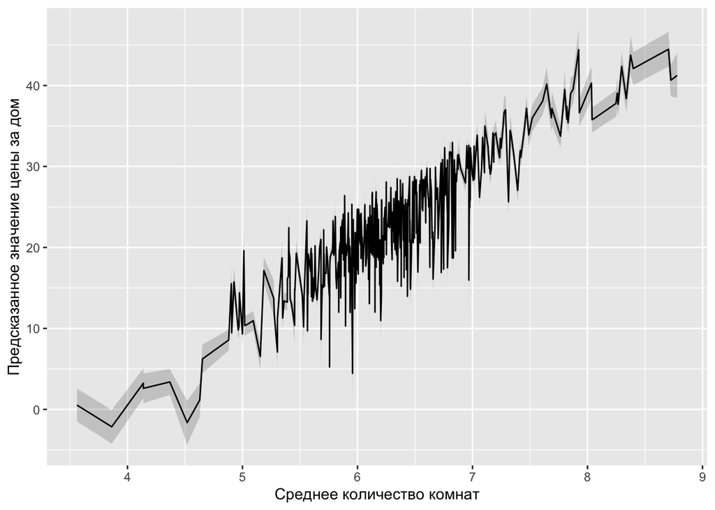

```r
predictions <- predict(house_model_final_unsc,  interval = 'confidence')
predictions_full_data <- data.frame(houses, predictions)

ggplot(predictions_full_data, aes(x = rm, y = fit)) +
  geom_ribbon(alpha = 0.2, aes(ymin = lwr, ymax = upr)) +
  geom_line() +
  xlab('Среднее количество комнат') +
  ylab('Предсказанное значение цены за дом')
```

Проверим, что у убранных предикторов нет звисимости

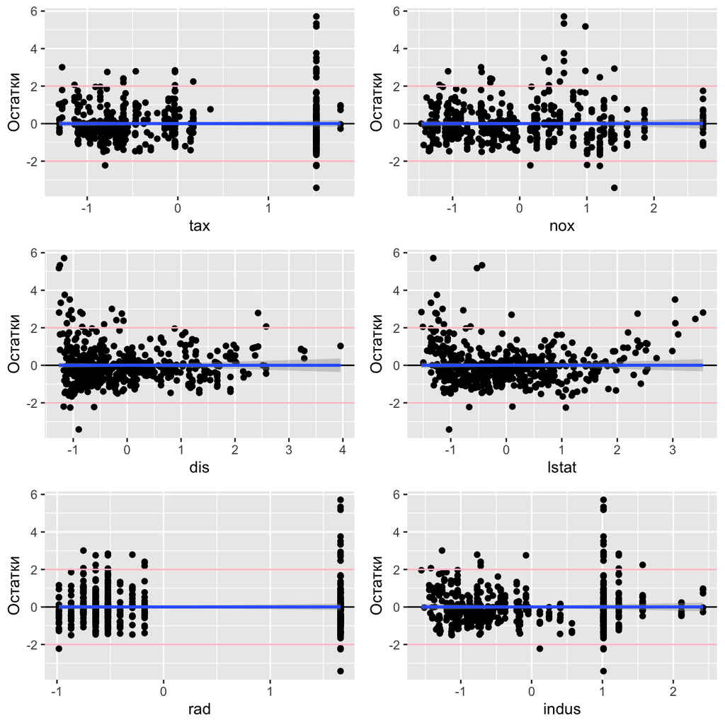

```r
plot_model <- ggplot(data = house_model_plot, aes(x = .fitted, y = .std.resid)) +
  geom_point() +
  geom_hline(yintercept = 0) +
  geom_smooth(method = "lm") +
  geom_hline(yintercept = 2, color = "pink") +
  geom_hline(yintercept = -2, color = "pink") +
  xlab('Предсказанное значение') +
  ylab('Oстатки')
grid.arrange(plot_model + aes(tax),
             plot_model + aes(nox),
             plot_model + aes(dis),
             plot_model + aes(lstat),
             plot_model + aes(rad),
             plot_model + aes(indus))
```

Предикторы можно не возвращать

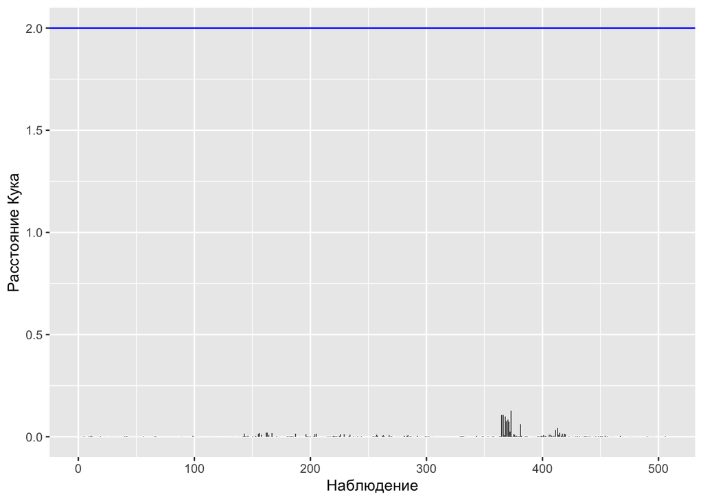

```r
house_model_plot_unsc <- data.frame(fortify(house_model_final_unsc), houses[, c(1, 2, 4, 6, 7, 11, 12)])
ggplot(house_model_plot_unsc, aes(x = 1:nrow(house_model_plot_unsc), y = .cooksd)) +
  geom_bar(stat = "identity") +
  geom_hline(yintercept = 2, color = "blue") +
  xlab('Наблюдение') +
  ylab('Расстояние Кука')
```

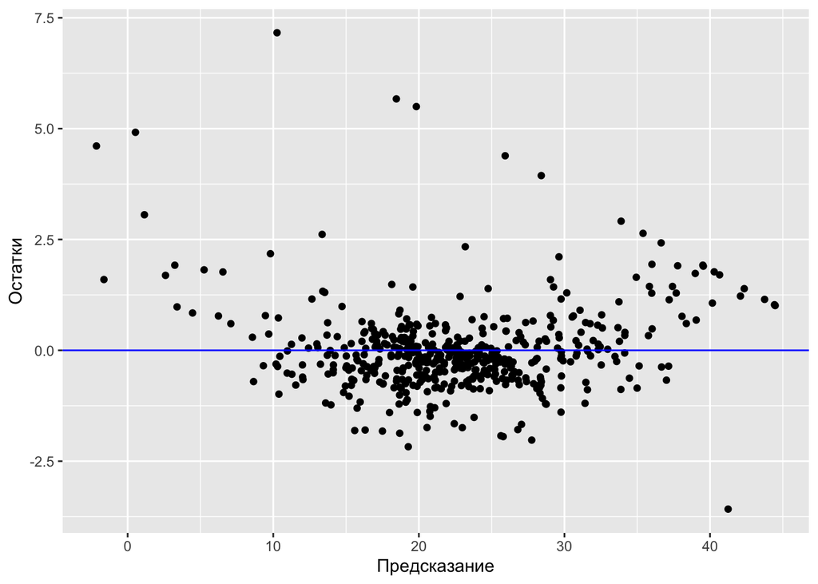

```r
house_model_plot <- data.frame(augment(house_model_final_unsc), houses[, c()])
ggplot(data = house_model_plot, aes(.fitted, .std.resid)) +
  geom_point() +
  geom_hline(yintercept = 0, color = 'blue') +
  xlab('Предсказание') +
  ylab('Oстатки')
```

```r
shapiro.test(house_model_plot$.std.resid)
```

```
##
##  Shapiro-Wilk normality test
##
## data:  house_model_plot$.std.resid
## W = 0.83143, p-value < 2.2e-16
```

Видим, что моделька не стала сильно лучше, честно говоря(

## Рекомендации заказчику

Итоговая модель:

Если дом не у реки - medv = -7.06 - 0.108 * crim - 0.003 * zn + 7.06 * rm - 0.04 * age - 0.927 * ptratio + 0.015 * black

Если у реки - medv = -3.54 - 0.108 * crim - 0.003 * zn + 7.06 * rm - 0.04 * age - 0.927 * ptratio + 0.015 * black

1. Дом у реки дроже на 3,5 тысячи
2. При снижении уровня преступности цена вырастает незначительно (на 0.108 тысяч)
3. Доля земель под жилую застройку изменяет цену совсем незначительно (0.003)
4. Цена дома сильно зависит от количества комнат, вырастает на 7.06 тысяч с увеличением комнат
5. При уменьшении доли старых домов (построенных до 1940 года) цена вырастает на 0.04 тысячи
6. Уменьшение соотношения количества учеников на учителей увеличивает стоимость дома на 0.927 тысяч
7. black - ололололо, ничего не знаю

Таким образом, идеальный район:

- находится у реки
- имеет дома с большим количеством комнат
- имеет на территории школу с маленькими классами (чтобы соотношение ученики-учитель было небольшое)
- имеет мало старых домов в округе
- с низкой преступностью

Спасибо большое за курс! Вы супер!